# Exemplos de Anova

Arthur Goretti

Topicos em Zoologia 2 - 2/2018

# Analise de variancia - ANOVA

Utilizamos esta analise para saber se existe diferencia entre fatores Saber se a diferencia das medias sao reais ou casuais. Observamos a variancia dentro dos grupos para saber se existe diferencia entre os grupos

## Valor de F

F = (Variabilidade do fator/V. resudual)/V. residual F = 1: As medias sao similares F > 1: As medias sao diferentes

H0 = As populacoes estudadas sao iguais (m1 = m2 = m3 = m4) H1 = As populacoes estudadas sao diferentes

## Premissas

1. Interdependencia das amostras
2. Homocedasticidade (Variancias comparaveis ou variancias iguais)
3. Distribuicao normal (Teste parametrico)

# One way ANOVA —-

Neste anova iremos comparar um unico fator. Temos mais de duas amostras e queremos saber se existe diferencia real entre as medias.

```r
library(tidyverse)
```

Ex 1. Contamos a quantidade de frutos em 4 individuos de de cinco especies de lenhosas do Cerrado.

```r
dfrutos <-
  tibble(jatoba = c(17, 11, 16, 12),
         cagaita = c(13, 18, 16, 17),
         copaiba = c(16, 16, 19, 21),
         araticum = c(15, 12, 15, 14),
         baru = c(17, 11, 16, 12)) |>
  pivot_longer(1:5,
               names_to="sp",
               values_to="frutos") |>
  arrange(sp) |>
  mutate(sp=as_factor(sp))
dfrutos
```

```
## # A tibble: 20 × 2
##    sp       frutos
##    <fct>     <dbl>
##  1 araticum     15
##  2 araticum     12
##  3 araticum     15
##  4 araticum     14
##  5 baru         17
##  6 baru         11
##  7 baru         16
##  8 baru         12
##  9 cagaita      13
## 10 cagaita      18
## 11 cagaita      16
## 12 cagaita      17
## 13 copaiba      16
## 14 copaiba      16
## 15 copaiba      19
## 16 copaiba      21
## 17 jatoba       17
## 18 jatoba       11
## 19 jatoba       16
## 20 jatoba       12
```

Existe diferencia real entre as medias das amostras? (p = 0.05) Criaremos uma tabela para fazer a analise Variaveis dependentes que sejam continuos e variaveis Variaveis independentes que sejam classes ou fatores

Visualizando nossos dados:

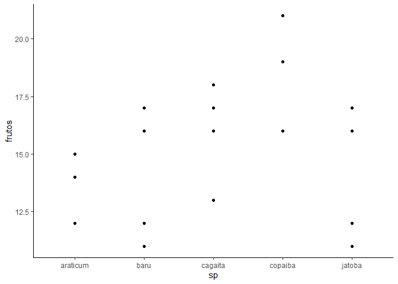

```r
dfrutos |>
  ggplot(aes(sp, frutos))+
  geom_point()+
  theme_classic()
```

## Premissas

### 1. Normalidade

```r
gfrutos <-
  dfrutos |>
  group_by(sp) |>
  group_split()
names(gfrutos) <- levels(dfrutos$sp)
```

```r
gfrutos |>
  map("frutos") |>
  map(~shapiro.test(.))
```

```
## $araticum
##
##  Shapiro-Wilk normality test
##
## data:  .
## W = 0.82743, p-value = 0.1612
##
##
## $baru
##
##  Shapiro-Wilk normality test
##
## data:  .
## W = 0.88207, p-value = 0.3476
##
##
## $cagaita
##
##  Shapiro-Wilk normality test
##
## data:  .
## W = 0.92708, p-value = 0.5774
##
##
## $copaiba
##
##  Shapiro-Wilk normality test
##
## data:  .
## W = 0.86038, p-value = 0.2616
##
##
## $jatoba
##
##  Shapiro-Wilk normality test
##
## data:  .
## W = 0.88207, p-value = 0.3476
```

### 2. Homocedasticidade

Usaremos o test de levene que calcula a homocedasticidade H0 = variancia entre os grupos igual levene.test(y = vetor numerico, group = fator dos dados)

```r
library(lawstat)
levene.test(dfrutos$frutos, group = dfrutos$sp)
```

```
##
##  Modified robust Brown-Forsythe Levene-type test based on the absolute
##  deviations from the median
##
## data:  dfrutos$frutos
## Test Statistic = 1.8214, p-value = 0.1772
```

### 3. Independencia das amostras

Contamos frutos de cada arvore, entao temos certeza que sao independentes!

## Finalmente a ANOVA one way!

aov(formula = y variando em relacao a X, data = tabela)

```r
resultado <- aov(frutos ~ sp, data = dfrutos)
summary(resultado)
```

```
##             Df Sum Sq Mean Sq F value Pr(>F)
## sp           4   51.2    12.8   2.133  0.127
## Residuals   15   90.0     6.0
```

### Como interpretar? Olhar o valor de F e confirmar com o valor de p

# Two way ANOVA —-

Neste caso, temos dois fatores Queremos saber se a producao de frutos difere entre as especies e dentro de replicas em cerrados sensu stricto.

```r
dfrutos2 <-
  tibble(tingui = c(16, 13, 19, 9, 15, 11, 22, 25, 17, 10, 11, 9, 13, 14, 21),
barbatimao = c(18, 17, 21, 15, 13, 12, 14, 16, 12, 11, 8, 22, 7, 15, 10),
tamboril = c(14, 12, 13, 7, 12, 9, 11, 14, 12, 5, 10, 8, 9, 4, 10),
ipe = c(21, 20, 16, 15, 16, 21, 25, 17, 14, 22, 15, 21, 20, 23, 21)) |>
  pivot_longer(1:4,
               names_to="sp",
               values_to="frutos") |>
  arrange(sp) |>
  mutate(sp=as_factor(sp),
         local=as_factor(rep(c(rep("grandesertao",5),
                     rep("veadeiros",5),
                     rep("brasilia",5)),
                   4)))
dfrutos2
```

```
## # A tibble: 60 × 3
##    sp         frutos local
##    <fct>       <dbl> <fct>
##  1 barbatimao     18 grandesertao
##  2 barbatimao     17 grandesertao
##  3 barbatimao     21 grandesertao
##  4 barbatimao     15 grandesertao
##  5 barbatimao     13 grandesertao
##  6 barbatimao     12 veadeiros
##  7 barbatimao     14 veadeiros
##  8 barbatimao     16 veadeiros
##  9 barbatimao     12 veadeiros
## 10 barbatimao     11 veadeiros
## # ℹ 50 more rows
```

## Tabela

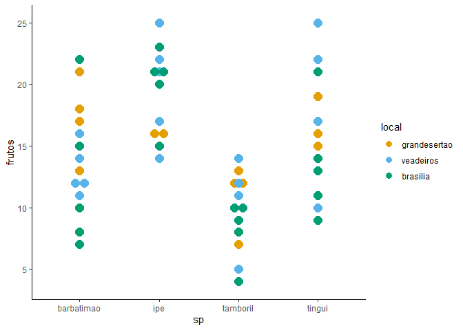

```r
library(ggokabeito)
dfrutos2 |>
  ggplot(aes(sp,
             frutos,
             color=local,
             fill=local))+
  geom_dotplot(binaxis = "y", stackdir = "center")+
  theme_classic()+
  scale_okabe_ito(c("color",
                    "fill"))
```

## 1. Normalidade

### 1.1. Normalidade do fator especie

```r
dfrutos2_sp <-
dfrutos2 |>
  group_by(sp) |>
  group_split()
names(dfrutos2_sp) <-
  dfrutos2_sp |>
  map_chr(~as.character(.$sp[1]))
```

```r
dfrutos2_sp |>
  map(~shapiro.test(.$frutos))
```

```
## $barbatimao
##
##  Shapiro-Wilk normality test
##
## data:  .$frutos
## W = 0.97836, p-value = 0.9571
##
##
## $ipe
##
##  Shapiro-Wilk normality test
##
## data:  .$frutos
## W = 0.92327, p-value = 0.216
##
##
## $tamboril
##
##  Shapiro-Wilk normality test
##
## data:  .$frutos
## W = 0.94566, p-value = 0.4589
##
##
## $tingui
##
##  Shapiro-Wilk normality test
##
## data:  .$frutos
## W = 0.93637, p-value = 0.3389
```

### 1.2. Normalidade do fator local

Neste caso, precisamos testar a normalidade com os dados de media de producao em cada local, para isso criamos um comando com essa condicao: shapiro.test dos valores de quantidade quando o local seja igual a x.

```r
dfrutos2_local <-
dfrutos2 |>
  group_by(local) |>
  group_split()
names(dfrutos2_local) <-
  dfrutos2_local |>
  map_chr(~as.character(.$local[1]))
```

```r
dfrutos2_local |>
  map(~shapiro.test(.$frutos))
```

```
## $grandesertao
##
##  Shapiro-Wilk normality test
##
## data:  .$frutos
## W = 0.968, p-value = 0.7122
##
##
## $veadeiros
##
##  Shapiro-Wilk normality test
##
## data:  .$frutos
## W = 0.93597, p-value = 0.201
##
##
## $brasilia
##
##  Shapiro-Wilk normality test
##
## data:  .$frutos
## W = 0.90946, p-value = 0.06224
```

## 2. Homocedasticidade

```r
levene.test(dfrutos2$frutos, group = dfrutos2$sp)
```

```
##
##  Modified robust Brown-Forsythe Levene-type test based on the absolute
##  deviations from the median
##
## data:  dfrutos2$frutos
## Test Statistic = 1.2432, p-value = 0.3027
```

```r
levene.test(dfrutos2$frutos, group = dfrutos2$local)
```

```
##
##  Modified robust Brown-Forsythe Levene-type test based on the absolute
##  deviations from the median
##
## data:  dfrutos2$frutos
## Test Statistic = 2.5277, p-value = 0.08876
```

# Two way ANOVA

Neste caso, precisamos especificar que usaremos dois fatores Para analisar o fator especie e o fator local, utilizamos o simbolo +

```r
resultado2 <- aov(frutos ~ sp + local, dfrutos2)
summary(resultado2)
```

```
##             Df Sum Sq Mean Sq F value   Pr(>F)
## sp           3  632.2  210.73   13.16 1.45e-06 ***
## local        2   30.1   15.05    0.94    0.397
## Residuals   54  864.6   16.01
## ---
## Signif. codes:  0 '***' 0.001 '**' 0.01 '*' 0.05 '.' 0.1 ' ' 1
```

Qual o resultado? A variacao na quantidade de frutos entre especies e/ou entre locais?

## Two way ANOVa com interacao

Para analisar a interacao da especie com o local, utilizamos o simbolo “:”.

```r
resultado3 <- aov(frutos ~ sp+local+sp:local, data = dfrutos2)
summary(resultado3)
```

```
##             Df Sum Sq Mean Sq F value   Pr(>F)
## sp           3  632.2  210.73  13.323 1.88e-06 ***
## local        2   30.1   15.05   0.952    0.393
## sp:local     6  105.4   17.56   1.110    0.370
## Residuals   48  759.2   15.82
## ---
## Signif. codes:  0 '***' 0.001 '**' 0.01 '*' 0.05 '.' 0.1 ' ' 1
```

# Teste post hoc - Teste de Tukey —-

Observamos que ha variacao entre as medias, mas quais medias variam entre elas? Sera que todas sao diferentes ou nao?

```r
posth <- TukeyHSD(resultado2)
posth
```

```
##   Tukey multiple comparisons of means
##     95% family-wise confidence level
##
## Fit: aov(formula = frutos ~ sp + local, data = dfrutos2)
##
## $sp
##                           diff        lwr        upr     p adj
## ipe-barbatimao       5.0666667   1.193546  8.9397875 0.0055649
## tamboril-barbatimao -4.0666667  -7.939788 -0.1935458 0.0361132
## tingui-barbatimao    0.9333333  -2.939788  4.8064542 0.9189687
## tamboril-ipe        -9.1333333 -13.006454 -5.2602125 0.0000004
## tingui-ipe          -4.1333333  -8.006454 -0.2602125 0.0321881
## tingui-tamboril      5.0000000   1.126879  8.8731209 0.0063598
##
## $local
##                         diff       lwr      upr     p adj
## veadeiros-grandesertao -0.10 -3.149415 2.949415 0.9965626
## brasilia-grandesertao  -1.55 -4.599415 1.499415 0.4438011
## brasilia-veadeiros     -1.45 -4.499415 1.599415 0.4904038
```

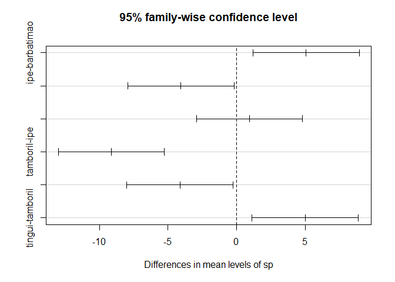

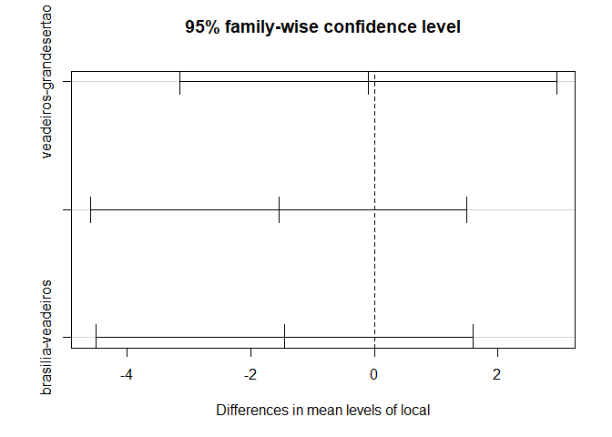

```r
plot(posth)
```

Quando a barra cruzar o zero no eixo x, significa que a diferenca entre esses grupos nao e significativo. Se a diferencia for positiva, a media do primeiro fator e maior que do segundo fator.

Quais sao as medias que nao tem diferencias significativas?